# Miami Housing Statics

```python
# Standard Imports
import pandas as pd
import numpy as np
import scipy.stats as stats
import matplotlib.pyplot as plt
import seaborn as sns
from sklearn.model_selection import train_test_split
from sklearn.linear_model import LogisticRegression
from sklearn.metrics import classification_report
import statsmodels.formula.api as smf
%matplotlib inline
#Visualization
import matplotlib
import matplotlib.pyplot as plt
import seaborn as sns
import plotly.express as px

#Machine Learming Model
from sklearn.linear_model import LogisticRegression
from sklearn.naive_bayes import GaussianNB
from sklearn.naive_bayes import MultinomialNB
from sklearn.metrics import confusion_matrix
from sklearn.metrics import classification_report
from sklearn.metrics import f1_score
from sklearn.linear_model import LogisticRegression
from sklearn.model_selection import train_test_split
from sklearn.metrics import accuracy_score
from sklearn.metrics import confusion_matrix
from sklearn.metrics import classification_report
```

```python
# Import Data
import ssl
ssl._create_default_https_context = ssl._create_unverified_context

import certifi
from sklearn.datasets import fetch_openml

# Download the dataset from openml
dataset = fetch_openml(data_id=44983, as_frame=True)
# Extract feature matrix X and show 5 random samples
house= dataset["frame"]
house.sample(5)
```

|  | LATITUDE | LONGITUDE | SALE_PRC | LND_SQFOOT | TOT_LVG_AREA | SPEC_FEAT_VAL | RAIL_DIST | OCEAN_DIST | WATER_DIST | CNTR_DIST | SUBCNTR_DI | HWY_DIST | age | avno60plus | month_sold | structure_quality |
| --- | --- | --- | --- | --- | --- | --- | --- | --- | --- | --- | --- | --- | --- | --- | --- | --- |
| 8011 | 25.633140 | -80.444264 | 300000.0 | 5306.0 | 1946.0 | 1344.0 | 1843.2 | 45644.0 | 32305.2 | 97851.6 | 47516.5 | 19494.3 | 18.0 | 0.0 | 12.0 | 4.0 |
| 6730 | 25.825881 | -80.361226 | 364000.0 | 4581.0 | 1599.0 | 3641.0 | 13784.2 | 54022.9 | 15820.1 | 58229.7 | 43638.8 | 8313.1 | 27.0 | 0.0 | 11.0 | 5.0 |
| 6659 | 25.806024 | -80.331411 | 1017000.0 | 4752.0 | 3855.0 | 9865.0 | 3950.1 | 41908.3 | 3772.6 | 46846.3 | 31482.4 | 3365.2 | 0.0 | 0.0 | 6.0 | 5.0 |
| 2566 | 25.846489 | -80.154261 | 419000.0 | 7140.0 | 1459.0 | 0.0 | 11109.0 | 11595.5 | 321.0 | 28297.6 | 21716.5 | 13080.2 | 26.0 | 0.0 | 2.0 | 4.0 |
| 780 | 25.887570 | -80.228781 | 139000.0 | 9372.0 | 898.0 | 2944.0 | 5597.8 | 35256.0 | 2581.1 | 41972.8 | 41972.8 | 6421.2 | 54.0 | 0.0 | 5.0 | 4.0 |

```python
#lets look at the data frame that we created
house.head()
```

|  | LATITUDE | LONGITUDE | SALE_PRC | LND_SQFOOT | TOT_LVG_AREA | SPEC_FEAT_VAL | RAIL_DIST | OCEAN_DIST | WATER_DIST | CNTR_DIST | SUBCNTR_DI | HWY_DIST | age | avno60plus | month_sold | structure_quality |
| --- | --- | --- | --- | --- | --- | --- | --- | --- | --- | --- | --- | --- | --- | --- | --- | --- |
| 0 | 25.891031 | -80.160561 | 440000.0 | 9375.0 | 1753.0 | 0.0 | 2815.9 | 12811.4 | 347.6 | 42815.3 | 37742.2 | 15954.9 | 67.0 | 0.0 | 8.0 | 4.0 |
| 1 | 25.891324 | -80.153968 | 349000.0 | 9375.0 | 1715.0 | 0.0 | 4359.1 | 10648.4 | 337.8 | 43504.9 | 37340.5 | 18125.0 | 63.0 | 0.0 | 9.0 | 4.0 |
| 2 | 25.891334 | -80.153740 | 800000.0 | 9375.0 | 2276.0 | 49206.0 | 4412.9 | 10574.1 | 297.1 | 43530.4 | 37328.7 | 18200.5 | 61.0 | 0.0 | 2.0 | 4.0 |
| 3 | 25.891765 | -80.152657 | 988000.0 | 12450.0 | 2058.0 | 10033.0 | 4585.0 | 10156.5 | 0.0 | 43797.5 | 37423.2 | 18514.4 | 63.0 | 0.0 | 9.0 | 4.0 |
| 4 | 25.891825 | -80.154639 | 755000.0 | 12800.0 | 1684.0 | 16681.0 | 4063.4 | 10836.8 | 326.6 | 43599.7 | 37550.8 | 17903.4 | 42.0 | 0.0 | 7.0 | 4.0 |

```python
#let’s look at what data types our variables have
house.info()
#all our variables are float64
```

```
<class 'pandas.core.frame.DataFrame'>
RangeIndex: 13932 entries, 0 to 13931
Data columns (total 16 columns):
 #   Column             Non-Null Count  Dtype
---  ------             --------------  -----
 0   LATITUDE           13932 non-null  float64
 1   LONGITUDE          13932 non-null  float64
 2   SALE_PRC           13932 non-null  float64
 3   LND_SQFOOT         13932 non-null  float64
 4   TOT_LVG_AREA       13932 non-null  float64
 5   SPEC_FEAT_VAL      13932 non-null  float64
 6   RAIL_DIST          13932 non-null  float64
 7   OCEAN_DIST         13932 non-null  float64
 8   WATER_DIST         13932 non-null  float64
 9   CNTR_DIST          13932 non-null  float64
 10  SUBCNTR_DI         13932 non-null  float64
 11  HWY_DIST           13932 non-null  float64
 12  age                13932 non-null  float64
 13  avno60plus         13932 non-null  float64
 14  month_sold         13932 non-null  float64
 15  structure_quality  13932 non-null  float64
dtypes: float64(16)
memory usage: 1.7 MB
```

```python
#let’s see some basic things about each column.
house.describe()
```

|  | LATITUDE | LONGITUDE | SALE_PRC | LND_SQFOOT | TOT_LVG_AREA | SPEC_FEAT_VAL | RAIL_DIST | OCEAN_DIST | WATER_DIST | CNTR_DIST | SUBCNTR_DI | HWY_DIST | age | avno60plus | month_sold | structure_quality |
| --- | --- | --- | --- | --- | --- | --- | --- | --- | --- | --- | --- | --- | --- | --- | --- | --- |
| count | 13932.000000 | 13932.000000 | 1.393200e+04 | 13932.000000 | 13932.000000 | 13932.000000 | 13932.000000 | 13932.000000 | 13932.000000 | 13932.000000 | 13932.000000 | 13932.000000 | 13932.000000 | 13932.000000 | 13932.000000 | 13932.000000 |
| mean | 25.728811 | -80.327475 | 3.999419e+05 | 8620.879917 | 2058.044574 | 9562.493468 | 8348.548715 | 31690.993798 | 11960.285235 | 68490.327132 | 41115.047265 | 7723.770693 | 30.669251 | 0.014930 | 6.655828 | 3.513997 |
| std | 0.140633 | 0.089199 | 3.172147e+05 | 6070.088742 | 813.538535 | 13890.967782 | 6178.027333 | 17595.079468 | 11932.992369 | 32008.474808 | 22161.825935 | 6068.936108 | 21.153068 | 0.121276 | 3.301523 | 1.097444 |
| min | 25.434333 | -80.542172 | 7.200000e+04 | 1248.000000 | 854.000000 | 0.000000 | 10.500000 | 236.100000 | 0.000000 | 3825.600000 | 1462.800000 | 90.200000 | 0.000000 | 0.000000 | 1.000000 | 1.000000 |
| 25% | 25.620056 | -80.403278 | 2.350000e+05 | 5400.000000 | 1470.000000 | 810.000000 | 3299.450000 | 18079.350000 | 2675.850000 | 42823.100000 | 23996.250000 | 2998.125000 | 14.000000 | 0.000000 | 4.000000 | 2.000000 |
| 50% | 25.731810 | -80.338911 | 3.100000e+05 | 7500.000000 | 1877.500000 | 2765.500000 | 7106.300000 | 28541.750000 | 6922.600000 | 65852.400000 | 41109.900000 | 6159.750000 | 26.000000 | 0.000000 | 7.000000 | 4.000000 |
| 75% | 25.852269 | -80.258019 | 4.280000e+05 | 9126.250000 | 2471.000000 | 12352.250000 | 12102.600000 | 44310.650000 | 19200.000000 | 89358.325000 | 53949.375000 | 10854.200000 | 46.000000 | 0.000000 | 9.000000 | 4.000000 |
| max | 25.974382 | -80.119746 | 2.650000e+06 | 57064.000000 | 6287.000000 | 175020.000000 | 29621.500000 | 75744.900000 | 50399.800000 | 159976.500000 | 110553.800000 | 48167.300000 | 96.000000 | 1.000000 | 12.000000 | 5.000000 |

**Quality Investigation**

```python
# lets Check the number of duplicates while ignoring the index feature
n_duplicates = house.drop(labels=['LATITUDE'], axis=1).duplicated().sum()
#I picked Latitude Since

print(f"You seem to have {n_duplicates} duplicates in your database.")
```

```
You seem to have 0 duplicates in your database.
```

This shows me that this dataset has no duplicates in it.

```python
#Extract column names of all features, except 'LATITUDE'
#you may want to remove the target as well
columns_to_consider = house.drop(labels=['LATITUDE'], axis=1).columns

# Drop duplicates based on 'columns_to_consider'
house.drop_duplicates(subset=columns_to_consider, inplace=True)
house.shape
```

```
(13932, 16)
```

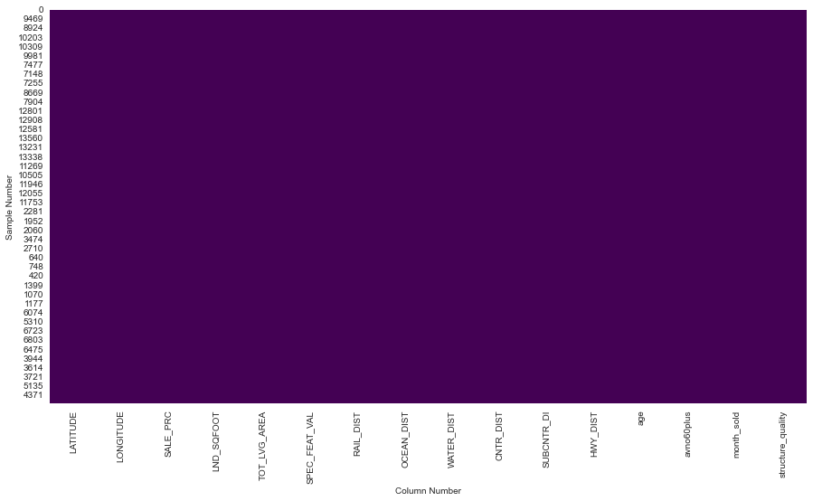

```python
# Missing Values (per sample/row)

plt.figure(figsize=(15, 8))
sns.set_style('whitegrid')


g = sns.heatmap(house.loc[house.isnull().sum(1).sort_values(ascending=True).index].isnull(), cbar=False, cmap='viridis')
g.set_xlabel('Column Number')
g.set_ylabel('Sample Number')
```

This tells me that there are no rows with alot of missing vaules that I should be deleting

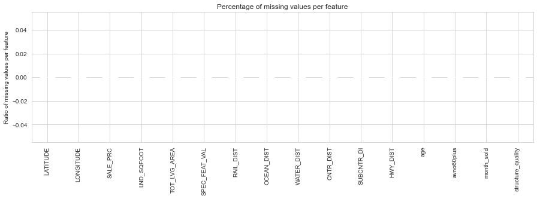

```python
# Per Feature / column
house.isna().mean().sort_values().plot(
    kind="bar", figsize=(15, 4),
    title="Percentage of missing values per feature",
    ylabel="Ratio of missing values per feature");
```

```python
house.shape
```

```
(13932, 16)
```

This diagram once again show us how there are not any big holes in the dataset

```python
# Drop rows that are 20% or more empty (you set the threshold)
house = house.dropna(thresh=house.shape[1] * 0.80, axis=0).reset_index(drop=True)
house.shape
#Since no row were more then 20% empty noting was deleted
```

```
(13932, 16)
```

Let’s now look at all the different variables that the numeric features have

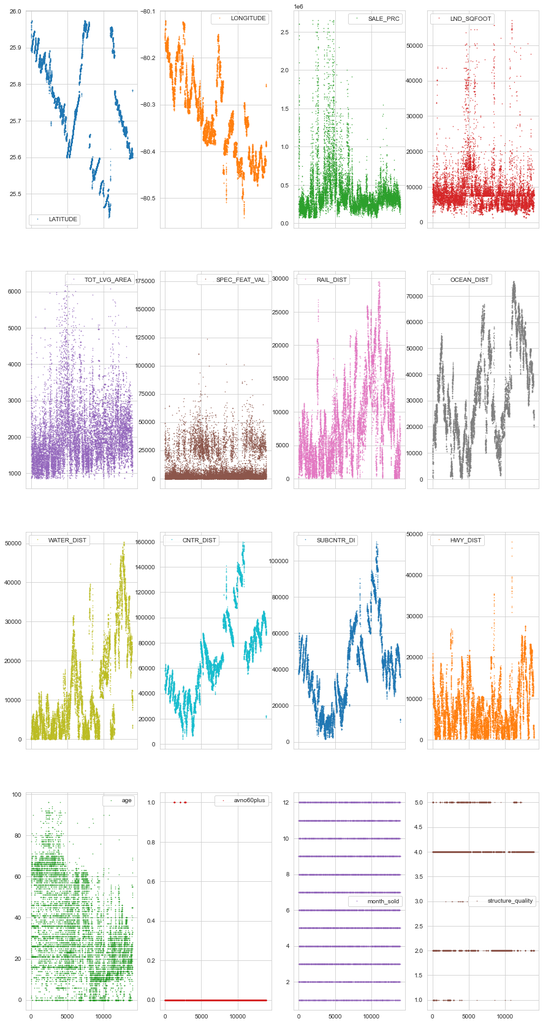

```python
# lets Plot all numeric features:
house.plot(lw=0, marker=".", subplots=True, layout=(-1, 4),
          figsize=(15, 30), markersize=1);
```

**Content Investigation**

Let’s now look a which values are the most common in our numeric columns

```
CPU times: total: 891 ms
Wall time: 1.01 s
```

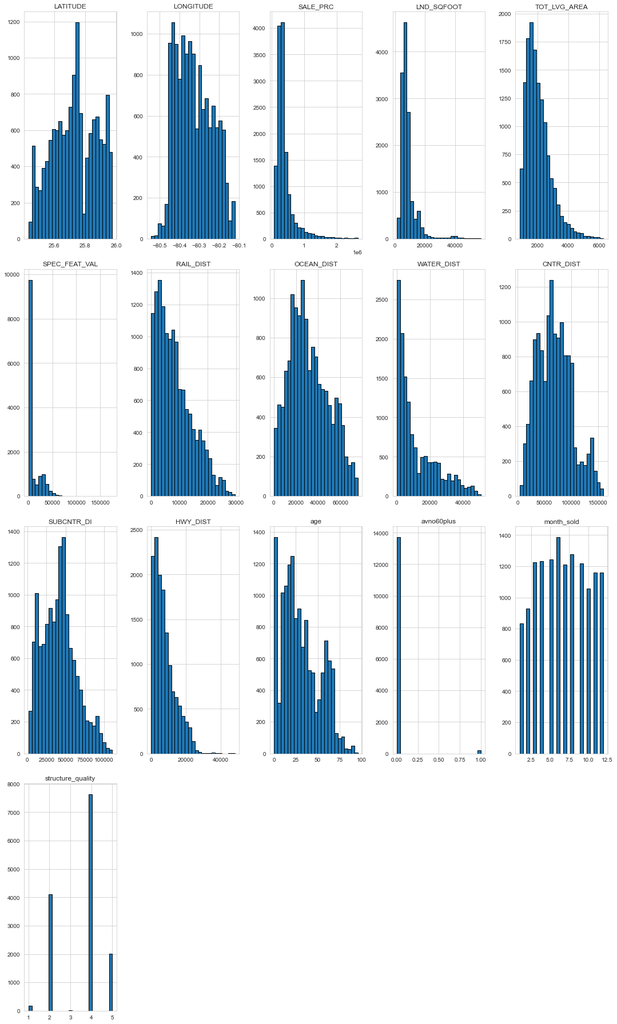

```python
%%time
# Feature Distribution
# Plots the histogram for each numerical feature in a separate subplot
house.hist(bins=25, figsize=(15, 25), layout=(-1, 5),
edgecolor="black")
plt.tight_layout();
```

This shows us things like how the most common size of the property that have been sold is close to 2000.

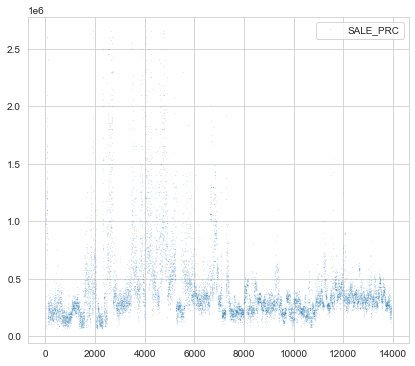

```python
# lets now look at the Features Patterns
house[["SALE_PRC"]].plot(

lw=0, marker=".", subplots=True, layout=(-1, 2), markersize=0.1,
figsize=(15, 6));
```

```
CPU times: total: 4min 41s
Wall time: 4min 51s
```

[figure not shown]

```python
%%time
# Specify features of interest
selected_features = ["SALE_PRC"]
# Create a figure with 3 x 2 subplots
fig, axes = plt.subplots(ncols=3, nrows=2, figsize=(16, 8))
# Loop through these features and plot entries from each feature against `Latitude`
for col, ax in zip(selected_features, axes.ravel()):
  sns.stripplot(data=house, x=col, y=house["LATITUDE"], ax=ax,palette="tab10", size=2, alpha=0.5)
  plt.tight_layout();
```

```python
# Feature Relationships
# Computes feature correlation
df_corr = house.corr(method="pearson")
```

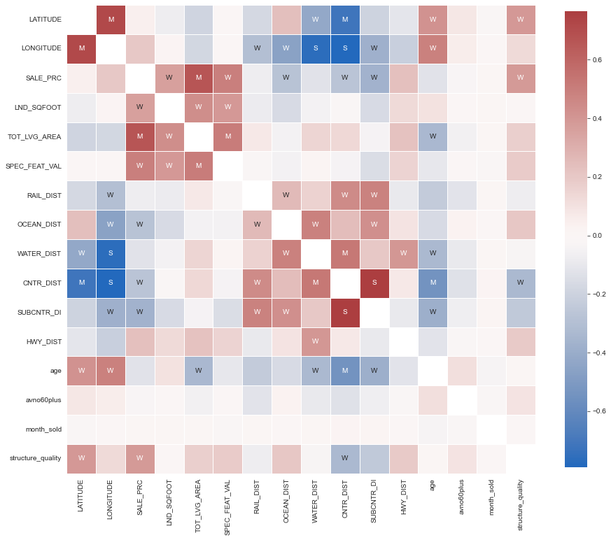

```python
# Create labels for the correlation matrix
labels = np.where(np.abs(df_corr)>0.75, "S",
np.where(np.abs(df_corr)>0.5, "M",
np.where(np.abs(df_corr)>0.25, "W", "")))
# Plot correlation matrix
plt.figure(figsize=(15, 15))
sns.heatmap(df_corr, mask=np.eye(len(df_corr)), square=True,
center=0, annot=labels, fmt='', linewidths=.5,
cmap="vlag", cbar_kws={"shrink": 0.8});
```

Lets create a regression model to see the correlation between TOT_LVG_AREA and WATER_DIST

```python
regression_object= smf.ols('WATER_DIST~TOT_LVG_AREA', data=house)
```

```python
regression_model= regression_object.fit()
```

Lets now look at a summary of this regression model

```python
regression_model.summary()
```

OLS Regression Results

| Dep. Variable: | WATER_DIST | R-squared: | 0.022 |
| --- | --- | --- | --- |
| Model: | OLS | Adj. R-squared: | 0.022 |
| Method: | Least Squares | F-statistic: | 313.4 |
| Date: | Wed, 26 Apr 2023 | Prob (F-statistic): | 2.24e-69 |
| Time: | 10:20:04 | Log-Likelihood: | -1.5039e+05 |
| No. Observations: | 13932 | AIC: | 3.008e+05 |
| Df Residuals: | 13930 | BIC: | 3.008e+05 |
| Df Model: | 1 |  |  |
| Covariance Type: | nonrobust |  |  |

|  | coef | std err | t | P>\|t\| | [0.025 | 0.975] |
| --- | --- | --- | --- | --- | --- | --- |
| Intercept | 7482.2010 | 271.985 | 27.510 | 0.000 | 6949.075 | 8015.327 |
| TOT_LVG_AREA | 2.1759 | 0.123 | 17.704 | 0.000 | 1.935 | 2.417 |

| Omnibus: | 1923.967 | Durbin-Watson: | 0.072 |
| --- | --- | --- | --- |
| Prob(Omnibus): | 0.000 | Jarque-Bera (JB): | 2826.672 |
| Skew: | 1.091 | Prob(JB): | 0.00 |
| Kurtosis: | 3.325 | Cond. No. | 6.02e+03 |

Notes:  
[1] Standard Errors assume that the covariance matrix of the errors is correctly specified.  
[2] The condition number is large, 6.02e+03. This might indicate that there are  
strong multicollinearity or other numerical problems.

lets now create a graph that shows us the correlation between TOT_LVG_AREA and WATER_DIST factors looks like

[figure not shown]

```python
plt.scatter(house['TOT_LVG_AREA'], house['WATER_DIST'],c='blue',marker='o')
plt.xlabel("TOT_LVG_AREA")
plt.ylabel("WATER_DIST")
plt.title ("Relationship between house size and distance to the ocean")
plt.axhline(house['WATER_DIST'].mean(),c='red',ls='--')
plt.yticks(np.arange(house['WATER_DIST'].min(), house['WATER_DIST'].max()+1, 5))

# This is the additional statement needed to plot the regression line in the scatterplot
plt.plot(house['TOT_LVG_AREA'], regression_model.predict(), c='red', ls='-')

plt.show()
```

```python
# Creates a mask to remove the diagonal and the upper triangle.
lower_triangle_mask = np.tril(np.ones(df_corr.shape),k=-1).astype("bool")
# Stack all correlations, after applying the mask
df_corr_stacked =df_corr.where(lower_triangle_mask).stack().sort_values()
# Showing the lowest and highest correlations in the correlation matrix
display(df_corr_stacked)
```

```
CNTR_DIST      LONGITUDE      -0.791968
WATER_DIST     LONGITUDE      -0.764256
CNTR_DIST      LATITUDE       -0.717348
age            CNTR_DIST      -0.548287
OCEAN_DIST     LONGITUDE      -0.457477
                                 ...
SPEC_FEAT_VAL  TOT_LVG_AREA    0.506064
CNTR_DIST      WATER_DIST      0.526952
TOT_LVG_AREA   SALE_PRC        0.667301
LONGITUDE      LATITUDE        0.721232
SUBCNTR_DI     CNTR_DIST       0.766387
Length: 120, dtype: float64
```

```python
house.corrwith(house["SALE_PRC"])
```

```
LATITUDE             0.047701
LONGITUDE            0.195274
SALE_PRC             1.000000
LND_SQFOOT           0.363077
TOT_LVG_AREA         0.667301
SPEC_FEAT_VAL        0.497500
RAIL_DIST           -0.077009
OCEAN_DIST          -0.274675
WATER_DIST          -0.127938
CNTR_DIST           -0.271425
SUBCNTR_DI          -0.370078
HWY_DIST             0.231877
age                 -0.123408
avno60plus          -0.027026
month_sold           0.000325
structure_quality    0.383995
dtype: float64
```

**Feature Importance**

```python
from sklearn.preprocessing import RobustScaler
scaler = RobustScaler()
```

**Encodeing Categorical data**

```python
#lets look the data types of our datasets.
house.dtypes
```

```
LATITUDE             float64
LONGITUDE            float64
SALE_PRC             float64
LND_SQFOOT           float64
TOT_LVG_AREA         float64
SPEC_FEAT_VAL        float64
RAIL_DIST            float64
OCEAN_DIST           float64
WATER_DIST           float64
CNTR_DIST            float64
SUBCNTR_DI           float64
HWY_DIST             float64
age                  float64
avno60plus           float64
month_sold           float64
structure_quality    float64
dtype: object
```

My data set only has numeric values. It is because of this that I will focus on numerical data.

```python
numerics = ['float64']
catDF = house.select_dtypes(exclude=numerics)
numDF = house.select_dtypes(include=numerics)
```

```python
numDF.head()
```

|  | LATITUDE | LONGITUDE | SALE_PRC | LND_SQFOOT | TOT_LVG_AREA | SPEC_FEAT_VAL | RAIL_DIST | OCEAN_DIST | WATER_DIST | CNTR_DIST | SUBCNTR_DI | HWY_DIST | age | avno60plus | month_sold | structure_quality |
| --- | --- | --- | --- | --- | --- | --- | --- | --- | --- | --- | --- | --- | --- | --- | --- | --- |
| 0 | 25.891031 | -80.160561 | 440000.0 | 9375.0 | 1753.0 | 0.0 | 2815.9 | 12811.4 | 347.6 | 42815.3 | 37742.2 | 15954.9 | 67.0 | 0.0 | 8.0 | 4.0 |
| 1 | 25.891324 | -80.153968 | 349000.0 | 9375.0 | 1715.0 | 0.0 | 4359.1 | 10648.4 | 337.8 | 43504.9 | 37340.5 | 18125.0 | 63.0 | 0.0 | 9.0 | 4.0 |
| 2 | 25.891334 | -80.153740 | 800000.0 | 9375.0 | 2276.0 | 49206.0 | 4412.9 | 10574.1 | 297.1 | 43530.4 | 37328.7 | 18200.5 | 61.0 | 0.0 | 2.0 | 4.0 |
| 3 | 25.891765 | -80.152657 | 988000.0 | 12450.0 | 2058.0 | 10033.0 | 4585.0 | 10156.5 | 0.0 | 43797.5 | 37423.2 | 18514.4 | 63.0 | 0.0 | 9.0 | 4.0 |
| 4 | 25.891825 | -80.154639 | 755000.0 | 12800.0 | 1684.0 | 16681.0 | 4063.4 | 10836.8 | 326.6 | 43599.7 | 37550.8 | 17903.4 | 42.0 | 0.0 | 7.0 | 4.0 |

**Normalize or Scaleing your Data**

```python
# Scale all numeric columns
numDF = pd.DataFrame(scaler.fit_transform(numDF.values),columns=numDF.columns,index=numDF.index)
numDF.head()
```

|  | LATITUDE | LONGITUDE | SALE_PRC | LND_SQFOOT | TOT_LVG_AREA | SPEC_FEAT_VAL | RAIL_DIST | OCEAN_DIST | WATER_DIST | CNTR_DIST | SUBCNTR_DI | HWY_DIST | age | avno60plus | month_sold | structure_quality |
| --- | --- | --- | --- | --- | --- | --- | --- | --- | --- | --- | --- | --- | --- | --- | --- | --- |
| 0 | 0.685668 | 1.227810 | 0.673575 | 0.503187 | -0.124376 | -0.239598 | -0.487371 | -0.599679 | -0.397902 | -0.495046 | -0.112432 | 1.246825 | 1.28125 | 0.0 | 0.2 | 0.0 |
| 1 | 0.686932 | 1.273198 | 0.202073 | 0.503187 | -0.162338 | -0.239598 | -0.312070 | -0.682137 | -0.398496 | -0.480228 | -0.125843 | 1.523057 | 1.15625 | 0.0 | 0.4 | 0.0 |
| 2 | 0.686975 | 1.274768 | 2.538860 | 0.503187 | 0.398102 | 4.023522 | -0.305959 | -0.684970 | -0.400959 | -0.479680 | -0.126237 | 1.532667 | 1.09375 | 0.0 | -1.0 | 0.0 |
| 3 | 0.688829 | 1.282219 | 3.512953 | 1.328413 | 0.180320 | 0.629643 | -0.286409 | -0.700890 | -0.418938 | -0.473940 | -0.123082 | 1.572624 | 1.15625 | 0.0 | 0.4 | 0.0 |
| 4 | 0.689087 | 1.268572 | 2.305699 | 1.422341 | -0.193307 | 1.205614 | -0.345660 | -0.674955 | -0.399173 | -0.478190 | -0.118822 | 1.494850 | 0.50000 | 0.0 | 0.0 | 0.0 |

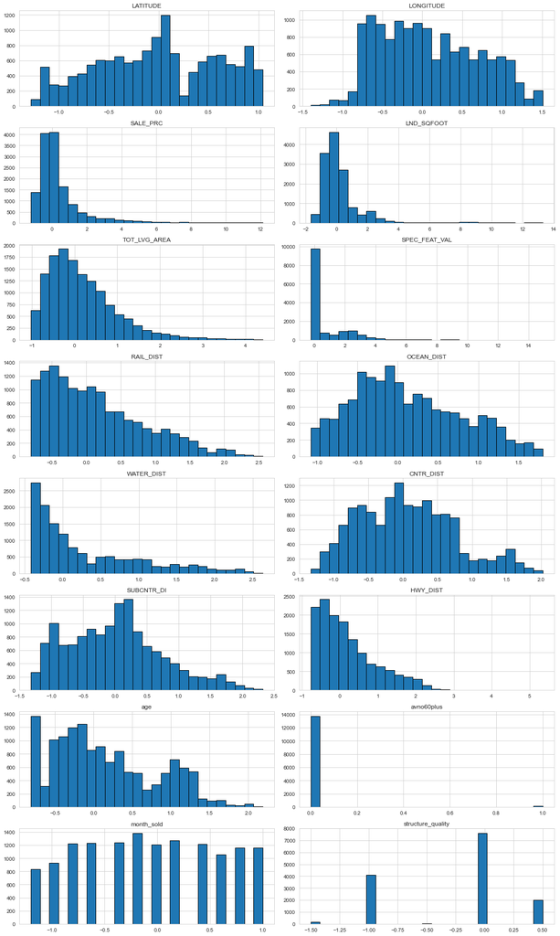

```python
# Feature Distribution
# Courtesy of Eladio
# Plots the histogram for each numerical feature in a separate subplot
numDF.hist(bins=25, figsize=(15, 25), layout=(-1, 2),
edgecolor="black")
plt.tight_layout();
#I am doing this again to see the a histogram of fetures after they have been Scaled
```

**Feature Selection**

```python
# Here I am dropping the variable that I want to predict
numDF.drop(['SALE_PRC'],axis=1,inplace=True)
```

```python
house['SALE_PRC']
```

```
0        440000.0
1        349000.0
2        800000.0
3        988000.0
4        755000.0
           ...
13927    275000.0
13928    340000.0
13929    287500.0
13930    315000.0
13931    250000.0
Name: SALE_PRC, Length: 13932, dtype: float64
```

Since my Y ('SALE_PRC') value wasn’t set as No and Yes, I converted all the houses that cost more than or equal to 500000 to 1(Yes) and all that are less than 500000 to 0(No). This allows me to then fit this dataset into a model.

```python
house['SALE_PRC']= house['SALE_PRC'].map(lambda x: 1 if x >= 500000 else 0)
```

```python
house['SALE_PRC']
```

```
0        0
1        0
2        1
3        1
4        1
        ..
13927    0
13928    0
13929    0
13930    0
13931    0
Name: SALE_PRC, Length: 13932, dtype: int64
```

```python
# Merge with the original dataframe
# Prepare the X variables
X = pd.concat([catDF, numDF],axis=1)
print(X.shape)
#Prepare the Y variable
Y = house['SALE_PRC']
```

```
(13932, 15)
```

**Feature Importance & Algorithm Harness**

Lets first creat our X and Y train and test variables

```python
from sklearn.model_selection import train_test_split
X_train, X_test, y_train, y_test = train_test_split(X,Y,test_size=0.3,random_state=100,stratify=Y)
```

```python
# First we build and train our Random Forest Model
from sklearn.ensemble import RandomForestClassifier
rf = RandomForestClassifier(max_depth=5, random_state=42, n_estimators = 300).fit(X_train, y_train)
rf.feature_importances_
# create a new DataFrame with feature importances and column names
feature_importances = pd.DataFrame({'feature': X.columns, 'importance': rf.feature_importances_})

# sort the features by importance
feature_importances = feature_importances.sort_values('importance', ascending=False)

# print the feature importances
print(feature_importances)
```

```
              feature  importance
3        TOT_LVG_AREA    0.244712
6          OCEAN_DIST    0.146854
9          SUBCNTR_DI    0.099341
4       SPEC_FEAT_VAL    0.093327
14  structure_quality    0.087754
2          LND_SQFOOT    0.084053
8           CNTR_DIST    0.078599
1           LONGITUDE    0.054298
0            LATITUDE    0.044748
10           HWY_DIST    0.025006
7          WATER_DIST    0.019242
11                age    0.015139
5           RAIL_DIST    0.005877
13         month_sold    0.000652
12         avno60plus    0.000398
```

```python
#Permutation Importance --- notice that it does NOT use a MODEL
from sklearn.inspection import permutation_importance
r = permutation_importance(rf, X_test, y_test,
                           n_repeats=10,
                           random_state=0)
perm = pd.DataFrame(columns=['AVG_Importance', 'STD_Importance'], index=[i for i in X_train.columns])
perm['AVG_Importance'] = r.importances_mean
```

```python
print(perm.to_string())
```

```
                   AVG_Importance STD_Importance
LATITUDE                 0.003325            NaN
LONGITUDE                0.003923            NaN
LND_SQFOOT               0.011579            NaN
TOT_LVG_AREA             0.055431            NaN
SPEC_FEAT_VAL            0.005622            NaN
RAIL_DIST                0.000120            NaN
OCEAN_DIST               0.023397            NaN
WATER_DIST               0.002368            NaN
CNTR_DIST                0.010287            NaN
SUBCNTR_DI               0.011148            NaN
HWY_DIST                 0.001292            NaN
age                      0.000598            NaN
avno60plus               0.000024            NaN
month_sold              -0.000263            NaN
structure_quality        0.008732            NaN
```

**Prediction model**

First lets look at the accuracy that accuracy a predction model using GaussianNB gives us.

```python
#lets first create the model
nb_classifier_house = GaussianNB()
```

```python
#lets now fit it
nb_classifier_house.fit(X_train, y_train)
```

```
GaussianNB()
```

```python
house_predicted_test= nb_classifier_house.predict(X_test)
```

```python
#lets now look at the confusion matrix for this model
confusion_matrix(y_test, house_predicted_test)
```

```
array([[3184,  216],
       [ 113,  667]], dtype=int64)
```

```python
#lets now print the classification report to see the accuracy of the model
print (classification_report (y_test, house_predicted_test))
```

```
              precision    recall  f1-score   support

           0       0.97      0.94      0.95      3400
           1       0.76      0.86      0.80       780

    accuracy                           0.92      4180
   macro avg       0.86      0.90      0.88      4180
weighted avg       0.93      0.92      0.92      4180
```

Using GaussianNB we got an accuracy of 0.92 with an f1-sore of 0.95 for 0 and 0.80 for 1.

Now lets lets look at the accuracy that a predction model using logistic regression gives us.

```python
# lets first create our model
logistic_model= LogisticRegression(max_iter= 1000)
```

```python
#lets now fit our logistic models
logistic_model.fit(X_train, y_train)
```

```
LogisticRegression(max_iter=1000)
```

```python
y_predicted_test= logistic_model.predict(X_test)
```

```python
#lets now look at the confusion matrix for this model
confusion_matrix(y_test, y_predicted_test)
```

```
array([[3323,   77],
       [ 161,  619]], dtype=int64)
```

```python
#lets now print the classification report to see the accuracy of the model
print (classification_report (y_test, y_predicted_test))
```

```
              precision    recall  f1-score   support

           0       0.95      0.98      0.97      3400
           1       0.89      0.79      0.84       780

    accuracy                           0.94      4180
   macro avg       0.92      0.89      0.90      4180
weighted avg       0.94      0.94      0.94      4180
```

Using logistic Regression we got an accuracy of 0.94 with an f1-sore of 0.97 for 0 and 0.84 for 1. This model gave us a higher accuracy with a .02 increase from the GaussianNB model it also had higher f1-score for both 0 and 1. Overall this model is the one we will be using to predict our 0 and 1.

We were able to create a predciton model that can predict if a propety will sell price would be more than 500,000 with an acurracy of 0.94.